Installing the packages:

```r
#install.packages("ggplot2")
#install.packages("palmerpenguins")
#install.packages("janitor")
#install.packages("dplyr")
#install.packages("tinytex")
```

Loading the packages:

```r
library(ggplot2)
library(palmerpenguins)
library(janitor)
library(dplyr)
library(tinytex)
```

Sourcing my functions:

```r
source("Functions/Cleaning.functions.R")
source("Functions/Graph.function.R")
source("Functions/plotting.R")
```

Observing the raw data:

```r
head(penguins_raw)
```

```
## # A tibble: 6 × 17
##   studyName `Sample Number` Species          Region Island Stage `Individual ID`
##   <chr>               <dbl> <chr>            <chr>  <chr>  <chr> <chr>
## 1 PAL0708                 1 Adelie Penguin … Anvers Torge… Adul… N1A1
## 2 PAL0708                 2 Adelie Penguin … Anvers Torge… Adul… N1A2
## 3 PAL0708                 3 Adelie Penguin … Anvers Torge… Adul… N2A1
## 4 PAL0708                 4 Adelie Penguin … Anvers Torge… Adul… N2A2
## 5 PAL0708                 5 Adelie Penguin … Anvers Torge… Adul… N3A1
## 6 PAL0708                 6 Adelie Penguin … Anvers Torge… Adul… N3A2
## # ℹ 10 more variables: `Clutch Completion` <chr>, `Date Egg` <date>,
## #   `Culmen Length (mm)` <dbl>, `Culmen Depth (mm)` <dbl>,
## #   `Flipper Length (mm)` <dbl>, `Body Mass (g)` <dbl>, Sex <chr>,
## #   `Delta 15 N (o/oo)` <dbl>, `Delta 13 C (o/oo)` <dbl>, Comments <chr>
```

Blotting a bad graph with the raw data

Plotting a bad graph:

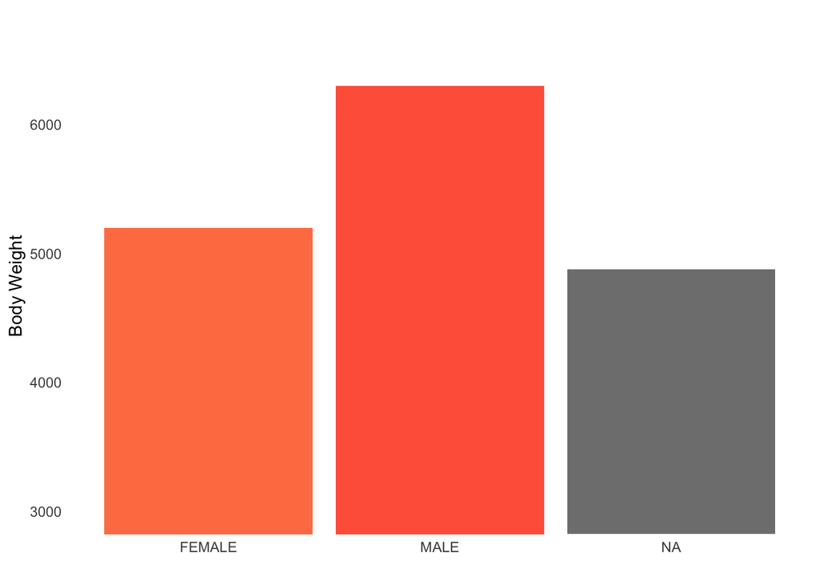

References: Yang, B. W., Vargas-Restrepo, C., Stanley, M. L., & Marsh, E. J. The Misleading Effect of Truncating Bar Graphs.

Introduction:

My analysis will investigate how body mass in the palmer penguins varies with flipper length. The palmer penguins species are the Chinstrap species, the Gentoo penguins, and the Adelie penguins. I am investigating to see if there might be a correlation between increasing flipper length and body mass. My hypothesis is that as flipper length increases, body mass will increase, as a consequence of the general morphology and dimensions of the birds remaining the same as flipper length increases (instead of perhaps, torso size decreasing). I will use a linear regression model to find out if there is a positive linear relationship between increasing flipper length and body mass.

Cleaning my data:

First I must save the raw data:

```r
write.csv(penguins_raw, "Data/penguins_raw.csv")
```

Cleaning my data:

```r
penguins_clean <- penguins_raw %>%
    clean_function() %>%
    shorten_species() %>%
    remove_empty_columns_rows()

#The above are functions that I made to clean the data. I have stored the functions in a folder in my repository called Functions. The file is called Cleaning.Functions.R, where I have explained the purpose of each function.


#Saving my cleaned data:

write.csv(penguins_clean, "Data/penguins_clean.csv")
```

```r
print(penguins_clean)
```

```
## # A tibble: 344 × 14
##    study_name sample_number species region island    stage         individual_id
##    <chr>              <dbl> <chr>   <chr>  <chr>     <chr>         <chr>
##  1 PAL0708                1 Adelie  Anvers Torgersen Adult, 1 Egg… N1A1
##  2 PAL0708                2 Adelie  Anvers Torgersen Adult, 1 Egg… N1A2
##  3 PAL0708                3 Adelie  Anvers Torgersen Adult, 1 Egg… N2A1
##  4 PAL0708                4 Adelie  Anvers Torgersen Adult, 1 Egg… N2A2
##  5 PAL0708                5 Adelie  Anvers Torgersen Adult, 1 Egg… N3A1
##  6 PAL0708                6 Adelie  Anvers Torgersen Adult, 1 Egg… N3A2
##  7 PAL0708                7 Adelie  Anvers Torgersen Adult, 1 Egg… N4A1
##  8 PAL0708                8 Adelie  Anvers Torgersen Adult, 1 Egg… N4A2
##  9 PAL0708                9 Adelie  Anvers Torgersen Adult, 1 Egg… N5A1
## 10 PAL0708               10 Adelie  Anvers Torgersen Adult, 1 Egg… N5A2
## # ℹ 334 more rows
## # ℹ 7 more variables: clutch_completion <chr>, date_egg <date>,
## #   culmen_length_mm <dbl>, culmen_depth_mm <dbl>, flipper_length_mm <dbl>,
## #   body_mass_g <dbl>, sex <chr>
```

Exploratory plot:

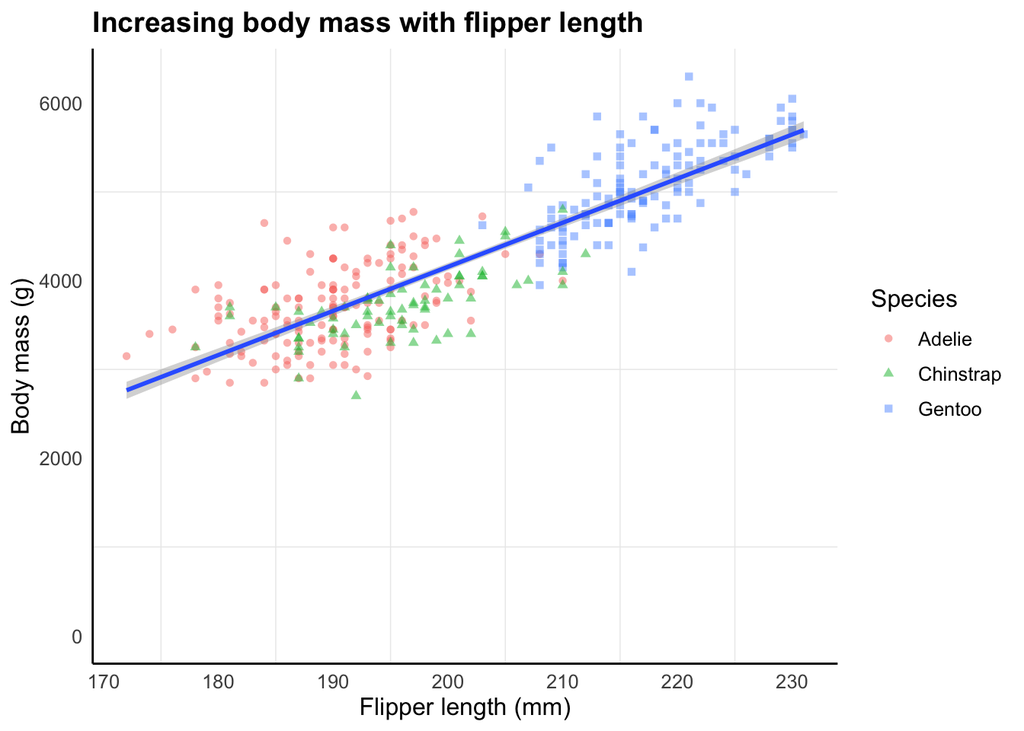

```r
#I made a function which makes my ggplot scatter plot. The function can be found in the file called Graph.function.R inside my functions folder in my repository.
penguin.scatterplot <- scatter.plot.flippers(penguins_clean)
penguin.scatterplot
```

Size, scale and resolution:

```r
#If the "ragg" package is not installed, install this package:
#install.packages("ragg")
library(ragg)
```

Saving the png file:

```r
save_scatter_plot_png(penguins_clean,
                      "figures/scatter.png",
                      size = 500, res = 300, scaling=0.25)
```

Creating vector images:

The image above is problematic because when you zoom in they are blurry because they are created by a matrix of pixels.

Saving my vector image:

```r
#If the svg package is not installed:
library(svglite)
#Saving the plot
save_flipper_plot_svg(penguins_clean,
                      "figures/scatter_vector.svg",
                      size = 15, scaling = 1)
```

Statistical tests:

```r
#Creating a linear model for my two variables:

linear_model <- lm(body_mass_g ~ flipper_length_mm, data = penguins_clean)

#Displaying the summary of the linear model:

summary(linear_model)
```

```
##
## Call:
## lm(formula = body_mass_g ~ flipper_length_mm, data = penguins_clean)
##
## Residuals:
##      Min       1Q   Median       3Q      Max
## -1058.80  -259.27   -26.88   247.33  1288.69
##
## Coefficients:
##                    Estimate Std. Error t value Pr(>|t|)
## (Intercept)       -5780.831    305.815  -18.90   <2e-16 ***
## flipper_length_mm    49.686      1.518   32.72   <2e-16 ***
## ---
## Signif. codes:  0 '***' 0.001 '**' 0.01 '*' 0.05 '.' 0.1 ' ' 1
##
## Residual standard error: 394.3 on 340 degrees of freedom
##   (2 observations deleted due to missingness)
## Multiple R-squared:  0.759,  Adjusted R-squared:  0.7583
## F-statistic:  1071 on 1 and 340 DF,  p-value: < 2.2e-16
```

### Results & Discussion

Link to my repository:

https://github.com/Mynewgithubabc/Penguin.Assignment.git

Link to my partner’s repository:

https://github.com/palmpeng1/assignment

My experience of running my partner’s code:

Running my partners code was straightforward as it is reproducible, meaning that other readers can easily understand and run the code. They have used piping to carry out multiple steps on the data frame at once without repeating multiple lines of code, making the code easier for me to understand. The piping step includes multiple new functions which my partner has created called clean_columns, clean_species etc that clean the data. They have explained before their piping code that the functions are stored in a separate file called cleaning.R instead of printing the entire code to make the functions in this R markdown. They have instead only called the functions in the pipe. Between each piping step my partner has annotated each step in the cleaning pipeline so it is easy to understand what each function in the pipeline is doing. My partner also created a function called plot_function which they have explained is stored in a plotting.R file. My partner only calls this function in their R markdown, avoiding repetition of many lines of code.

Keeping functions in a separate plotting.r and cleaning.r instead of writing the code in the note book and repeating it multiple times on different data sets is important as it keeps a safe copy of the original code that is version controlled. This allows you to revert any changes that were made to the graph or data. This is particularly important for graph functions as it allows you to make the exact same figure again, multiple times, on different datasets. Creating functions prevents the need to write the same lines of code out repeatedly making code easier to understand.

However, although my partner has explained that they have stored the functions in separate files, they have not explained the fact that they have made new functions (called clean_columns(), shortern_species(), etc that clean the data. Therefore if a new reader is not familiar with creating functions, they may not be able to follow the pipeline easily, or trouble shoot anything not working.

I did not encounter any errors in running my partners code However, since my partner has stored their functions in the separate folder called functions, and in a separate file called cleaning.R and plotting,r, it would be easy to navigate to find the functions and source any errors in their code.

Reflecting on my code based on my experience of my partner’s code and their review of my code:

• My partner suggested that I explain what the cleaning loops do in the chunk itself. I noted that they had done this in their code too. I agree with this, as it would help the reader to understand what my cleaning functions are doing without having to check the cleaning.r file for the explanation. This would make my code more human readable. My partner also suggested I create an extra file storing the package versions used in the analysis. I agree with this because it would allow the same analysis to be run in the future even if the packages have been updated, increasing reproducibility in the future. My partner suggested that I could use an ‘if’ loop to only install packages if they are not already installed. I agree with this as it would save time and computer energy. My partner noted that my file names for my functions are slightly confusing. My plotting.r is used for saving my plots, whereas my graph.functions.r is used for saving my graph functions. I have now realised that this is not human readable.

What I learnt about writing code for other people:

I found that my partner’s code was easier to interpret than my own. The biggest difference between mine and my partner’s code was that my partner used comments all the way through their code explaining what each step was doing. For example they stated where their functions were stored (for example in plotting.r), and they explained what each function in the pipe was doing. This was different to my code.My main notebook simply contains lines of code, without explaining what each line is doing. Although in my functions folder, (eg cleaning.r) I have explained what all my functions are doing, I find my partner’s version more human readable and therefore more reproduceable. I have also not included any explanation, analysis, or justification as to why I used a linear model to investigate the relationship between my two parameters, flipper length and body mass. This makes my analysis less human readable as it is difficult for another reader to grasp what calculations I am using and why. I have learnt that for other people to use the code it must be human readable. This means that the notebook is as simple as possible, with as few as possible lines of code. This was achieved for example by making functions and storing the lines of code to do this in separate functions such as cleaning.r.

If I was to complete this task again I would include annotations within the code explaining that these functions have been made, what they do, and where they are stored. This makes the code easy to interpret, so it is both computer and human readable.